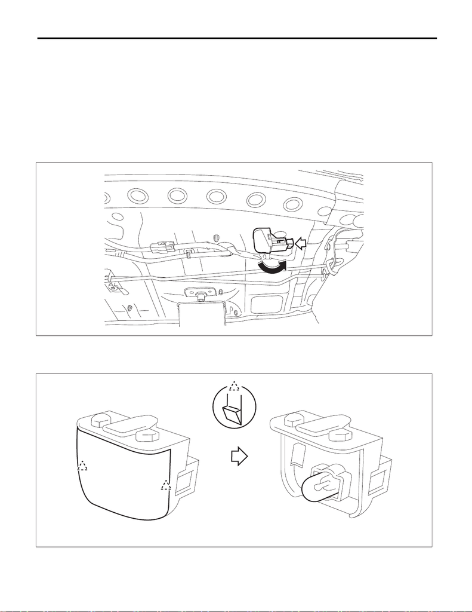

Trunk Room Light

LIGHTING SYSTEM

34.Trunk Room Light

A: REMOVAL

1) Disconnect the ground cable from battery. <Ref. to NT-5, BATTERY, NOTE, Note.>

NOTE:

For models other than STI model, disconnect the ground terminal from battery sensor.

2) Remove the light assembly - trunk room.

CAUTION:

When using a flat tip screwdriver, apply protective tape or cloth and be careful not to cause damage.

(1) Disconnect the connector.

(2) Turn the light assembly - trunk room counterclockwise to 60° and remove the light.

3) Release the claws and remove the lens and trunk room light bulb.

CAUTION:

Use a dry clean cloth so that no grease or water adheres to the glass portion of the bulb.

LI-01230

LI-01048

[figure not shown]

B: INSTALLATION

1) Install the trunk room light bulb and light assembly - trunk room.

CAUTION:

Use a dry clean cloth so that no grease or water adheres to the glass portion of the bulb.

2) Connect the battery ground terminal. <Ref. to NT-5, BATTERY, NOTE, Note.>

NOTE:

For models other than STI model, connect the ground terminal to battery sensor.